# Are the $200 free credits working?

Executive summary — 10,000 self-serve signups

Author

Patrick Kopps

Published

October 22, 2026

## Executive Summary

**Question:** Are the $200 credits working? Are they being used? Are we attracting freeloaders or builders with them?

**NoteAnswer**

**No. From a free to paid conversion perspective, the $200 credits are not working.** We granted $2,000,000 in credits across 10,000 signups and got 90 buyers from it, while 8,160 out of those 10,000 accounts never used the product at all.

### Definitions

**Builders definition**: Those who connect with an SDK or call the API **AND** return on 3 or more days **OR** use more than one product. They make up a small part of the signups and use 36.9% of their allotted credits on average.

**Freeloaders definition**: Those who used the free credits and did not buy. People who never called the API are not freeloaders. They did not engage.

*These definitions are created by me, and are exactly what we would put in a semantic layer.*

### Insights

- Business-email accounts are 1.7% likely to buy, compared to 0.7% for personal-email accounts. Business-email accounts buy about 2.5 times as often as personal-email signups.
- 993 of the 1,840 people who called the API did it on the day they signed up (54.0%).
- Speech-to-text is where most of the credits went ($26,894). The 100 heaviest accounts used $24,305, 46.6% of the $52,148 spent. The builder path, SDK and direct API, used $51,003, 97.8% of credits used. Console-only accounts used $1,146. Accounts that never connected spent $0. After speech-to-text, Text-to-speech used $15,769, Voice agent used $7,234, and Audio intelligence used $2,251.

## What Should the Business Do Instead?

**1. Give $150 at signup, not $200.** The 87 people who tried the product and bought used $141 on average. This may push some users over the edge to start buying. Too much credit and many people may not buy.

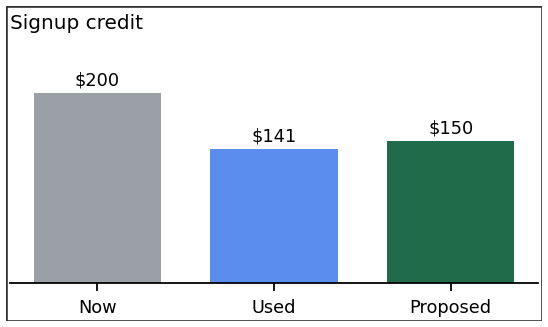

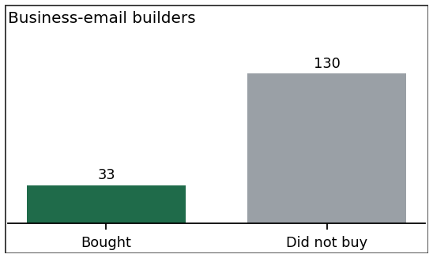

**2. Nudge the 163 business-email builders to the sales team, irrespective of whether they are tagged sales-qualified.** 33 of business-email builders bought. Of all 79 purchases that happened on or after signup (across all groups), 48 happened quickly within 7 days.

**3. AB Test the $150.** Instead of giving every self signup a $150 credit, AB test $150 vs $0, or $150 vs $100 vs $0, and measure the results. We cannot say the $200 credit caused the 90 buys, but it might have helped. A test will make this more clear and answer “would they have bought anyway without the credit?”

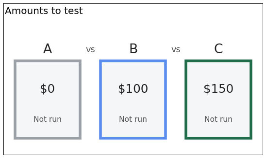

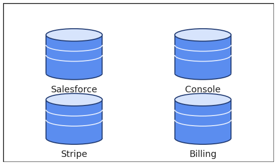

**4. Bring in more data.** We need to connect credits or trial usage with downstream revenue and longer-term engagement. Add post-trial spend (do users keep paying after credits run out or drop off?), the timeline between signup, credit use, and purchase, traffic source (where did they find us), and company size or sector. Tie accounts to actual paid activity beyond one-off purchases. This will let us track which users turn into long-term customers (LTV) and if different kinds of credits or nudges make a difference.

## Funnel

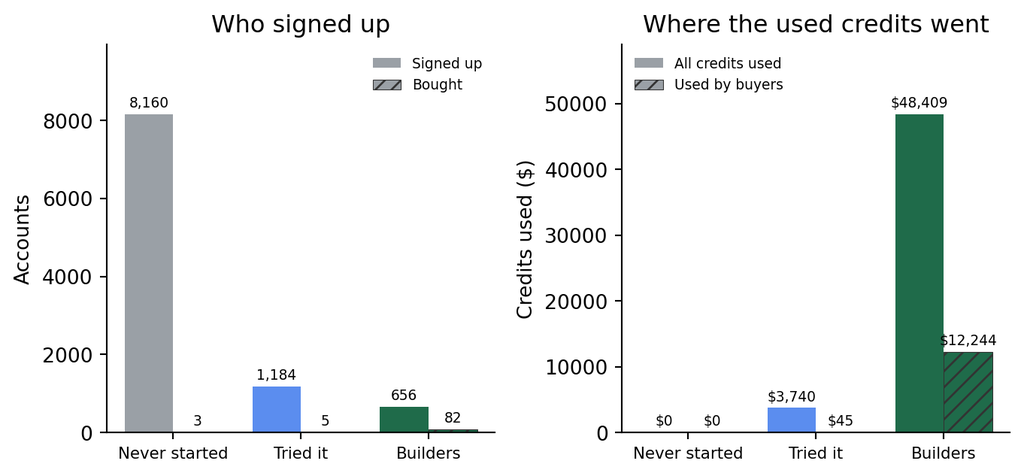

Figure 1: Signups and buyers in each group, and credits used by everyone versus credits used by buyers.

Out of 10,000 signups, 1,840 people tried the product at least once. Of those, 1,184 tried it but didn’t stick around, while 656 accounts became builders. 82 of those 656 builders went on to buy something. There are 120 accounts that used at least $100 of free credits but never bought anything — 118 of them still qualify as builders based on the definition.

We gave out $2,000,000 in credits. People spent just $52,148 total, which is 2.6% of what was given out. Buyers only used $12,288 of that (23.6% of credits actually spent). People who never bought used $39,860 (76.4% of credits actually spent). Almost all of that spend (92.8%) came from builders.

**Sales Team Leads.** We are reading this flag as the sales team saying the prospect is likely to buy. They were not. 19 of the 20 tagged accounts never bought. The one who did buy was tagged on 12 Feb 2026, after the purchase on 19 Jan 2026. None of the 20 were tagged and then bought.

**Revenue.** This file cannot say how much money the purchases brought in. `purchased` is yes or no, and `purchase_date` is only a date. There is no charge amount.

What we can count: 79 of the 90 purchase dates fall on or after signup, so those are the buys that could have come after the $200. The buyers consumed $12,288 in credits. That is usage, not cash collected. Another $4,987 was spent above the $200 grant, across 62 accounts, and 37 of those accounts are not marked as buyers. Do not treat that $4,987 as revenue either.

To get the revenue, join billing charges to these 10,000 accounts. Each charge needs the dollar amount, the date, and what it was for: a credit pack, an auto-load, or a Growth plan. Keep charges dated before signup out of the total for this offer.

## What to Watch Going Forward, and How to Watch it

Put the builder definition, the freeloader definition, and the metric/signal logic in the table below[^1] into a semantic layer. Run the same counts on every new signup file (or as new data comes into our database realistically). That is how the business keeps watching these credits, and future credit and incentive offer programs, not just from this one report, even if you were to refresh it or put it on a schedule.

This also makes the reporting more repeatable and less error-prone, allows for more confident and accurate reporting, and reduces the risk of misinterpretation or missed signals. It reduces the risk of one report saying one number, and another report saying another number. It helps keep definitions used for AB testing aligned between experiments. It allows non-technical users like PMs to run reports themselves. Semantic layers are immeasurably value-adding, and open tons of doors for the business.

Table 1

| Metric | Current | Description |
| --- | --- | --- |
| Credits used of the grant | 2.6% of $2,000,000 | Grant dollars actually spent. Act if this jumps. |
| Never called the API | 8,160 of 10,000 | No first API call. Do not give every signup the full $200. |
| Freeloaders (used credits, did not buy) | 1,753 of 1,840 | Called the API and did not buy. Act if this grows. |
| Business-email builders who buy | 33 of 163 | Business-email builders who bought. This is the sales list. |
| Buyers | 90 of 10,000 | Accounts marked purchased. Scorecard for the grant. |
| Tagged, then bought | 0 of 20 | Tag, then buy. The 1 purchase (19 Jan 2026) was tagged later (12 Feb 2026). |
| Purchases dated before signup | 11 of 90 | Purchase date is before signup. Do not count these as the credit working. |
| Used at least $100 and did not buy | 120 | Spent at least $100 and did not buy. Act if this grows. |
| Builder path share of credits used | 97.8% of $52,148 | Share used by SDK and direct API. Act if this falls. |
| Speech-to-text share of credits used | 51.6% of $52,148 | Share used on speech-to-text. Act if another product takes the lead. |
| Latest full month | February has 7 purchases, versus 12–19 earlier | Latest full month versus earlier months. Do not read a dip as worse conversion. |

## Appendix

### Callouts

**Buy before signup?** 11 of the 90 purchases are dated **before** signup, so they are not part of the expected funnel: 1. Signup, 2. Try the product using the $200 credit, 3. Buy.

**Pre-signup sales-qualified tags.** 16 of the 20 sales-qualified tags are dated before signup. A CRM join would show whether those people were already customers, or already in a sales conversation, before this account existed. Until that join, those tags are not evidence that the $200 worked.

**Recent signups.** February has 7 purchases, versus 12–19 earlier. Those accounts have had less time to buy, not because newer signups convert worse.

### QA

**Data quality.** The file is clean enough for the big picture: 10,000 unique accounts, the monthly spend list adds up, and no API call is dated before signup. 3 buyers never called the API. 29 called the API only after the purchase date. March is 45 signups, all on 1 Mar 2026. The file ends that day, so that month is one day, not a full month. The other months have 1,544–1,751 signups each. Do not read that short month as a drop.

## Footnotes

[^1]: Including but not limited to.